# CIPK OVC Key Performance Indicators (KPIs)

Presented by Roy Mwavita

Updated on 31_01_2025

# Introduction

This report covers the key performance indicators (KPIs) for the USAID TUJITEGEMEE Project.

Objectives of the KPIs:

- To evaluate the impact of the project on the targeted communities.
- To identify gaps in service delivery and areas for improvement.
- To track progress against set targets.

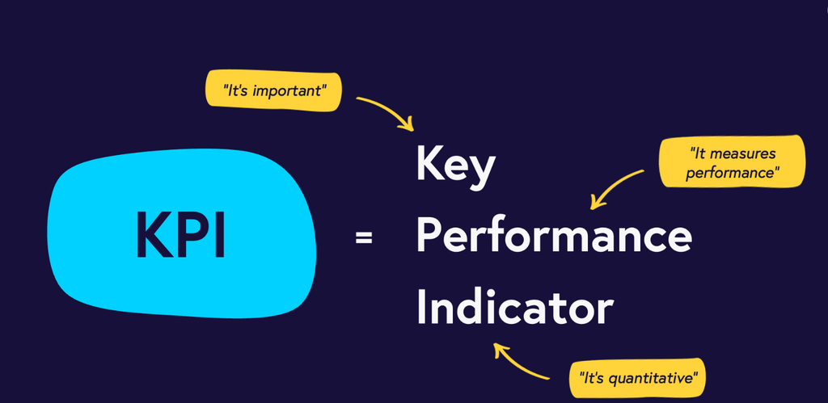

# COP Target

The COP targets are the President’s Emergency Plan for AIDS Relief (PEPFAR) **Country Operational Plan** (2022, 2023, 2024, etc.) targets.

These targets often involve indicators that measure key aspects of HIV prevention, treatment, and care, aiming to reduce the burden of HIV and improve health outcomes.  
For USAID TUJITEGEMEE project, the indicators are as follows:

- **OVC_SERV**
- **OVC_HIVSTAT**

In addition to these core indicators, the project also tracks a range of other key performance indicators that contribute to the overall measurement of the program’s impact.

These additional indicators provide a comprehensive view of the project’s effectiveness, including its reach, quality of services, and the improvements made in the lives of vulnerable populations.

| constituency | Comprehensive_COP_Target | Sinovuyo_Target | CBIM_Target | Graduation_Target | Total Targets |
| --- | --- | --- | --- | --- | --- |
| Kilifi North | 2823 | 354 | 274 | 809 | 4260 |
| Malindi | 1755 | 215 | 166 | 337 | 2473 |
| Total | 4578 | 569 | 440 | 1146 | 6733 |

# PEPFAR Monitoring: Going from Process to Impact

The overall goal of Orphans and Vulnerable (OVC) programming is to build the resiliency of families and children affected by HIV and AIDS so that they can meet their health, economic, education, and social development needs.

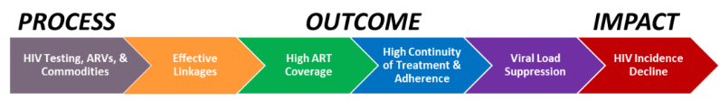

# **Data Sources**

The data for this analysis was collected from various reports downloaded from the Child Protection Information Management System (CPIMS) and PIMS.

**CPIMS REPORTS**

Registration List Report

Case Plan Report

Benchmark Report

List of OVC Served Report

Caregivers Served Report

HIV Risk Screening Report

Viral Load Report

Preventive Register

Preventive Attendance Report

Preventive Survey Report

**PIMS REPORTS**

DCF Report

Group Membership Report

Loan Tracker Report

On Path to Graduation Report

Ready to Graduate Report

Referral Report

HIV Management Report

HEI Tracking Report

# Comprehensive Target Achievement

| case_manager | Comprehensive_COP_Target | Active OVC Enrolled | Difference | Achievement % |
| --- | --- | --- | --- | --- |
| Dave Mainga | 956 | 1047 | -91 | 110% |
| Abdulnasir Mohammed | 1229 | 1229 | 0 | 100% |
| Ummu Bwanamkuu | 1044 | 1078 | -34 | 103% |
| Armon Thinga | 1349 | 1366 | -17 | 101% |
| Total | 4578 | 4720 | -142 | 103% |

# Sinovuyo Preventive Program

The Sinovuyo Program is an evidence-informed, 14-week parenting programme.

Teens (both boys and girls) between 10-14 years and not enrolled in a comprehensive program are considered eligible for Sinovuyo program.

**The Programme specifically aims to:**

Increase parenting knowledge, skill and confidence

Improve positive parenting behavior

Decrease harsh discipline

Increase teenagers’ self confidence

Increase teenagers’ sense of responsibility

Improve mental health and social support (both teenagers and parents)

Improve problem solving and communication skills (both teenagers and parents)

# Sinovuyo Implementation

| constituency | Sinovuyo_Target | Teens_Enrolled | Balance | Enrollment Achievement % | completed | not started | ongoing | Achievement % | Pre_not_done | Pre_done | Post_not_done |
| --- | --- | --- | --- | --- | --- | --- | --- | --- | --- | --- | --- |
| Kilifi North | 354 | 272 | 82 | 77% | 162 | 80 | 30 | 46% | 58 | 214 | 272 |
| Malindi | 215 | 275 | -60 | 128% | 232 | 25 | 18 | 108% | 10 | 265 | 275 |
| Total | 569 | 547 | 22 | 96% | 394 | 105 | 48 | 69% | 68 | 479 | 547 |

# CBIM Preventive Program

Coaching Boys Into Men (CBIM) is an evidence-based violence prevention program that trains and motivates high school coaches to teach their young male athletes in:

- healthy relationship skills,
- mental health practices,
- and that violence never equals strength through 12 weekly discussions in what is called the card series.

[figure not shown]

# CBIM Implementation

| constituency | CBIM_Target | Boys_Enrolled | Balance | Enrollment Achievement % | completed | not started | ongoing | Achievement % | Pre_not_done | Pre_done | Post_not_done | Post_done |
| --- | --- | --- | --- | --- | --- | --- | --- | --- | --- | --- | --- | --- |
| Kilifi North | 274 | 258 | 16 | 94% | 245 | 5 | 8 | 89% | 8 | 250 | 178 | 80 |
| Malindi | 166 | 189 | -23 | 114% | 173 | 4 | 12 | 104% | 1 | 188 | 188 | 1 |
| Total | 440 | 447 | -7 | 102% | 418 | 9 | 20 | 95% | 9 | 438 | 366 | 81 |

# Case Plan Achievement

Case plan achievement is a key component of the USAID TUJITEGEMEE project, focusing on supporting OVC and households through individualized goals to improve health, education, and economic outcomes.

Households and OVC can be **“graduated out”** of the program once they meet specific criteria, such as improved health, school retention, and economic stability.

Graduation signifies the success of interventions and the long-term sustainability of outcomes, empowering beneficiaries to thrive independently and reducing their dependency on external support.

| case_manager | Graduation_Target | OVC Graduated | Balance | Achievement % | HH Graduated | month1 | month2 | month3 |
| --- | --- | --- | --- | --- | --- | --- | --- | --- |
| Dave Mainga | 240 | 71 | 169 | 30% | 41 | 41 | 41 | 40 |
| Abdulnasir Mohammed | 308 | 0 | 308 | 0% | 0 | 0 | 0 | 0 |
| Ummu Bwanamkuu | 261 | 67 | 194 | 26% | 30 | 30 | 30 | 30 |
| Armon Thinga | 337 | 75 | 262 | 22% | 26 | 26 | 26 | 26 |
| Total | 1146 | 213 | 933 | 19% | 97 | 97 | 97 | 96 |

# Ready to Graduate Monitoring

| case_manager | HH Ready to Graduate | CPARA administered 0-3 months ago | OVC in HH Ready to Graduate | month1 |
| --- | --- | --- | --- | --- |
| Abdulnasir Mohammed | 6 | 6 | 12 | 6 |
| Ummu Bwanamkuu | 21 | 21 | 53 | 21 |
| Total | 27 | 27 | 65 | 27 |

# On Path to Graduation Monitoring (missing a score in benchmark 8)

| case_manager | HH Ready to Graduate | CPARA administered 0-3 months ago | CPARA administered 4-6 months ago | CPARA administered 7+ months ago | OVC in HH Ready to Graduate | month1 | month2 | month3 | NA_ |
| --- | --- | --- | --- | --- | --- | --- | --- | --- | --- |
| Abdulnasir Mohammed | 13 | 2 | 0 | 11 | 35 | 2 | 1 | 1 | 11 |
| Armon Thinga | 2 | 0 | 0 | 2 | 6 | 0 | 0 | 0 | 2 |
| Dave Mainga | 2 | 2 | 0 | 0 | 3 | 2 | 2 | 1 | 0 |
| Ummu Bwanamkuu | 9 | 0 | 1 | 8 | 19 | 0 | 0 | 0 | 9 |
| Total | 26 | 4 | 1 | 21 | 63 | 4 | 3 | 2 | 22 |

# OVC Comprehensive Eligibility

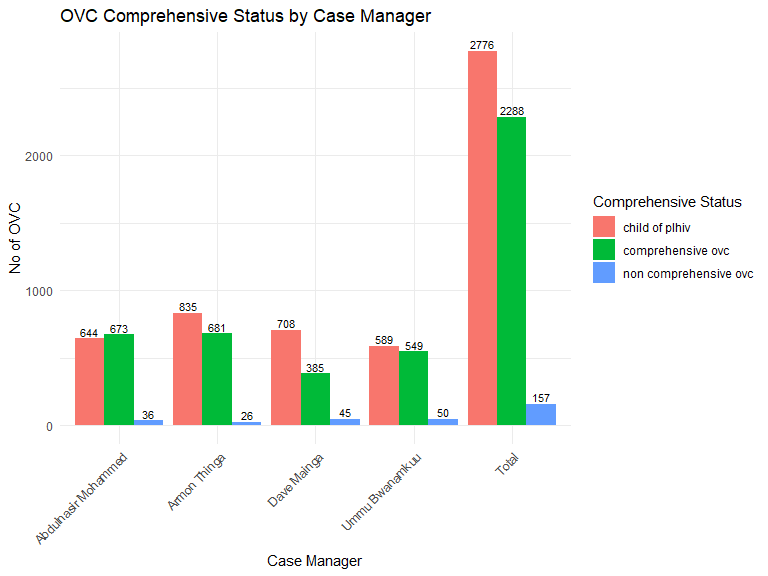

# Comprehensive Categorization

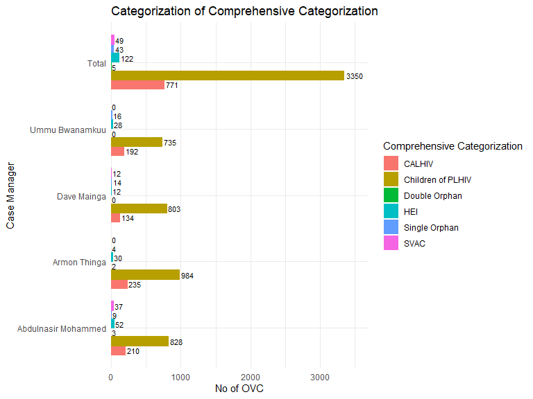

# Case Plan Achievement Readiness Assessment (CPARA)

Annual case plan achievement and readiness assessments (CPARA), facilitated by OVC case workers, measure HH achievement of OVC benchmarks and determines readiness to graduate. The CPARA categorizes each OVC HH into one of four vulnerability categories, based on graduation benchmark

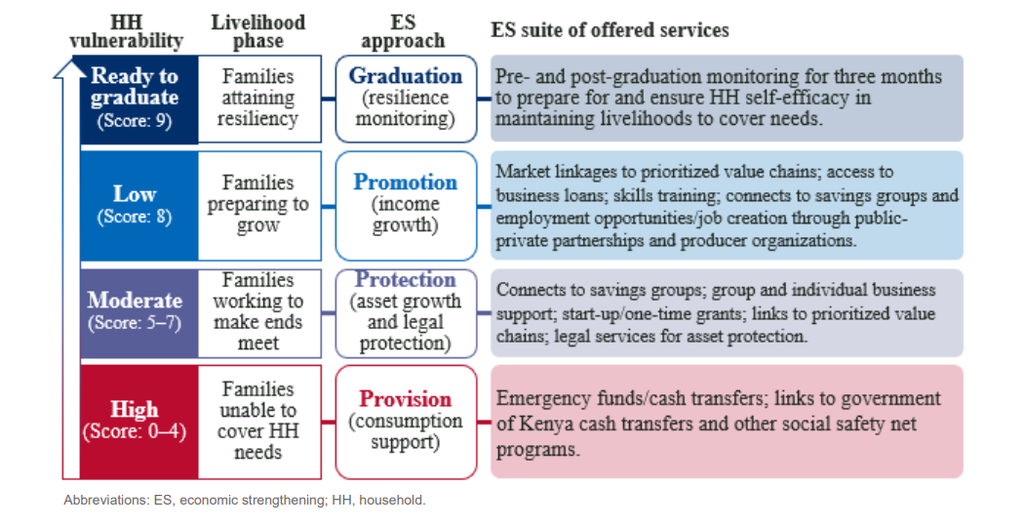

# CPARA Uptake

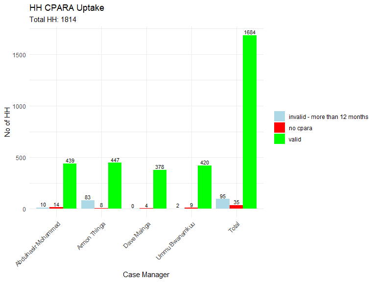

# Graduation Pathways

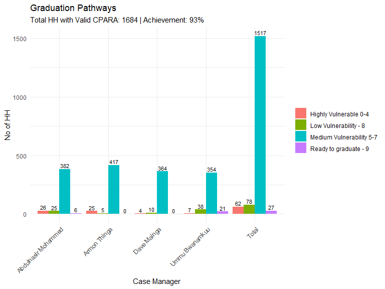

# Case Plan Uptake

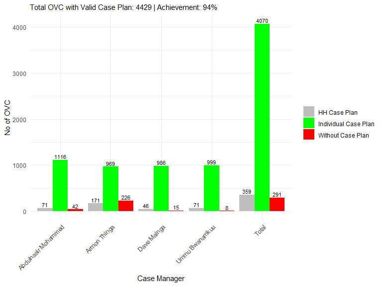

# Comprehensive_SERV Achievement

| case_manager | Enrolled OVC | served both quarters | not served | not served both quarters | served both quarters (newly enrolled and served) | served both quarters without caseplan | served one quarter (Q1) | Comprehensive_SERV |
| --- | --- | --- | --- | --- | --- | --- | --- | --- |
| Abdulnasir Mohammed | 1229 | 15 | 1 | 19 | 0 | 0 | 1194 | 1% |
| Armon Thinga | 1366 | 71 | 1 | 4 | 0 | 15 | 1275 | 5% |
| Dave Mainga | 1047 | 131 | 2 | 4 | 1 | 0 | 909 | 13% |
| Ummu Bwanamkuu | 1078 | 9 | 3 | 12 | 0 | 0 | 1054 | 1% |
| Total | 4720 | 226 | 7 | 39 | 1 | 15 | 4432 | 5% |

# Graphical Presentation of Comprehensive_SERV

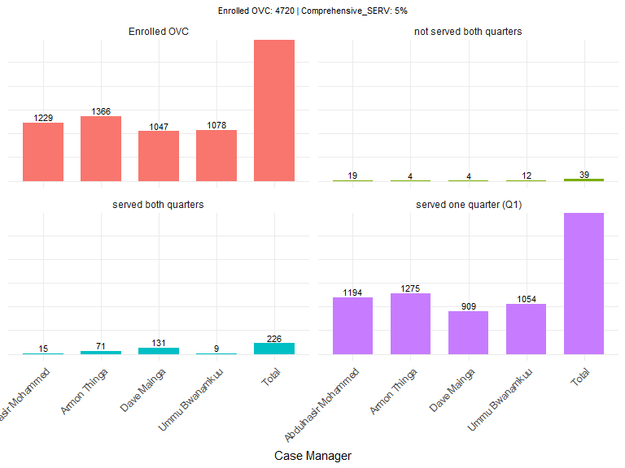

# OVC_SERV

- The goal of OVC programs is to build stability and resiliency in children and families who are exposed, living with, at risk of, or affected by HIV/AIDS. This is achieved through rigorous case management and provision of and access to health and socio-economic interventions.
- Therefore, OVC_SERV is a direct (output) measure of the number of individuals receiving PEPFAR OVC program services for children and families affected by HIV/AIDS across the 3 program models. *(MER 2.8, pg 50)*

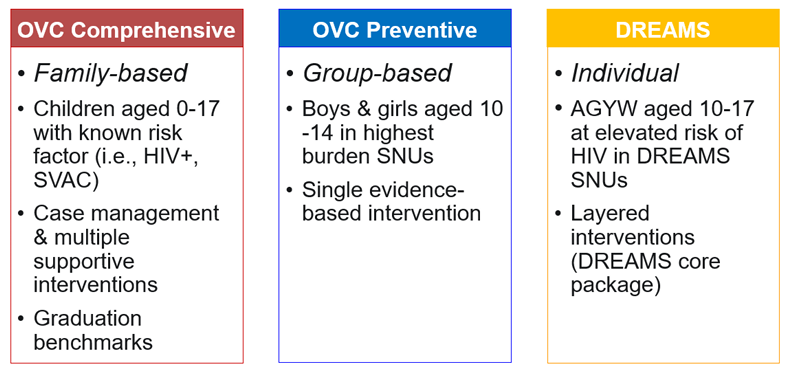

## How to calculate data for semi-annual results for OVC_SERV

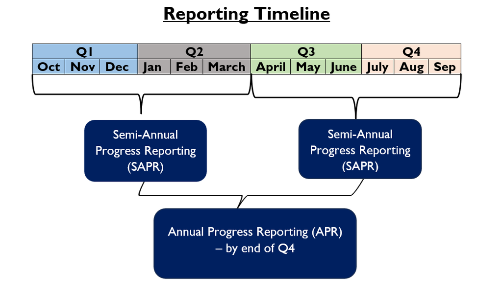

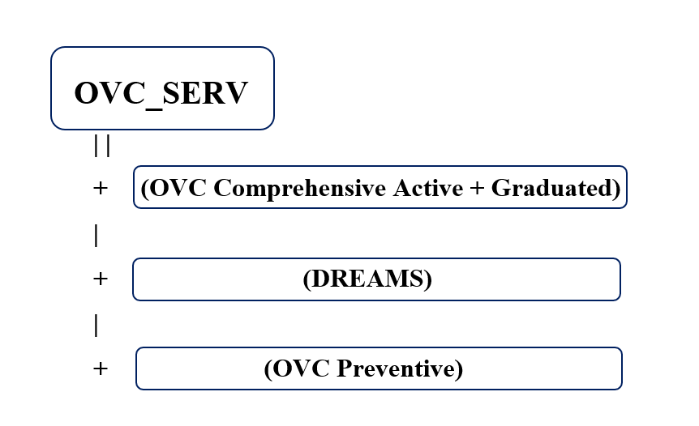